```python
%matplotlib inline
import pandas as pd
import numpy as np
import matplotlib
import matplotlib.pyplot as plt
import scipy
from scipy import stats
```

```python
# import library
import pickle

# open the file of interest, and use pickle loading
higgs_file = open ("higgs_100000_pt_250_500.pkl",'rb')
higgs_dict = pickle.load(higgs_file)

# list all keys of the files
higgs_dict.keys()
#data = np.array(new_dict.get('pt'))

qcd_file = open ("qcd_100000_pt_250_500.pkl",'rb')
qcd_dict = pickle.load(qcd_file)

qcd_dict.keys()
```

```
Index(['pt', 'eta', 'phi', 'mass', 'ee2', 'ee3', 'd2', 'angularity', 't1',
       't2', 't3', 't21', 't32', 'KtDeltaR'],
      dtype='object')
```

# Problem 1

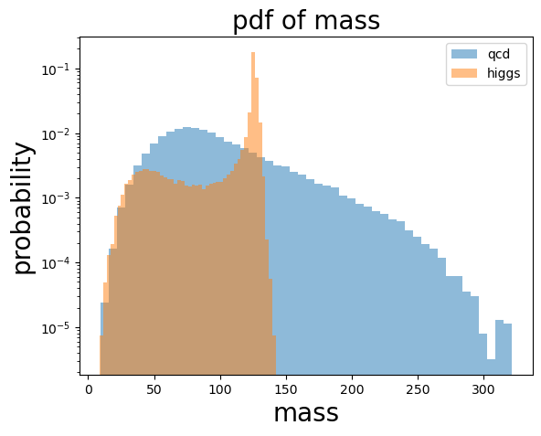

```python
plt.figure()
plt.hist(qcd_dict['mass'], bins = 50, density = True, alpha = 0.5)
plt.hist(higgs_dict['mass'], bins = 50, density = True, alpha = 0.5)
plt.legend(["qcd", "higgs"])
plt.title("pdf of mass", fontsize = 20)
plt.xlabel("mass", fontsize = 20)
plt.ylabel("probability", fontsize = 20)
plt.yscale('log')

plt.show()
```

```python
import math
p = stats.poisson.cdf(k=20100, mu=20000)
sigma = stats.norm.ppf(p)
print(sigma)
print(100/math.sqrt(20000))
```

```
0.7112259282313185
0.7071067811865475
```

N_higgs is the difference between the mean and measurement. sqrt(N_qcd) is the standard deviation of the Poisson distribution. With this in mind, the sigma value that we calculated (0.711) should be very similar to the equation since the difference of mean and measurement over standard deviation is the Z- score (0.707), and since Poisson is essentially a type of gaussian, sigma and z-score should be very similar.

# Problem 2

```python
# trial 1
print(higgs_dict['mass'].max())
cut = 143
mask1 = higgs_dict['mass'] < 143
n_higgs = higgs_dict['mass'][mask1].size/1000
mask2 = qcd_dict['mass'] < 143
n_qcd = (qcd_dict['mass'][mask2].size/100000)*20000
print(n_higgs/math.sqrt(n_qcd))
```

```
142.43960717193664
0.7644866727588414
```

```python
# trial 2
for x in range(110, 130):
    cut1 = x
    cut2 = 143

    mask1 = (higgs_dict['mass'] > cut1) & (higgs_dict['mass'] < cut2)
    n_higgs = higgs_dict['mass'][mask1].shape[0]/1000
    mask2 = (qcd_dict['mass'] > cut1) & (qcd_dict['mass'] < cut2)
    n_qcd = (qcd_dict['mass'][mask2].shape[0]/5)
    print(n_higgs/math.sqrt(n_qcd))
    print("from mass of " + str(x))
```

```
1.4616171451401732
from mass of 110
1.4903966806119502
from mass of 111
1.516202638480856
from mass of 112
1.5456373187371306
from mass of 113
1.5764752504666644
from mass of 114
1.6072481352286905
from mass of 115
1.6393088478490716
from mass of 116
1.6734795086184489
from mass of 117
1.7077381263256133
from mass of 118
1.7368124445413144
from mass of 119
1.7672804384460268
from mass of 120
1.7998746687322718
from mass of 121
1.8193001232951886
from mass of 122
1.8284339371933322
from mass of 123
1.796721893685018
from mass of 124
1.5749070435723136
from mass of 125
0.8557110093493826
from mass of 126
0.47636744875287085
from mass of 127
0.28873617186511874
from mass of 128
0.1507573721804518
from mass of 129
```

since Higgs doesn't have any signal with mass above 143, it's fair to assume to get rid of all qcd background with a mass of about 143. And from the data distribution, we can see the region with Higgs pick is around the mass of 115 - 135. So I set my lower bound within this region and do a for loop and found the lower bound with a mass of 123 produces the largest sigma.

# Problem 3

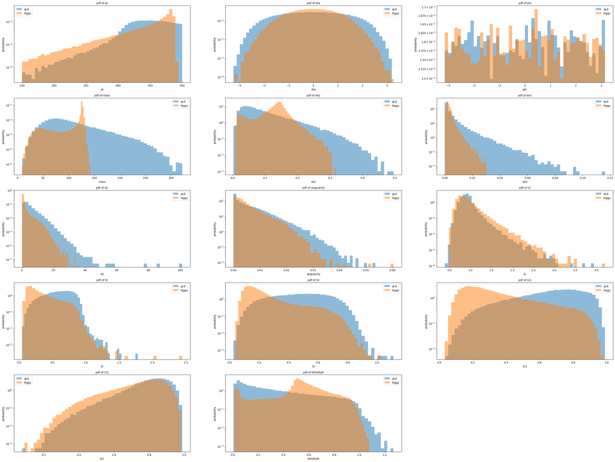

```python
fig = plt.figure(figsize=(40, 30))

rows = 5
columns = 3
n = 0

for x in qcd_dict.keys():
    n = n+1
    fig.add_subplot(rows, columns, n)
    plt.hist(qcd_dict[x], bins = 50, density = True, alpha = 0.5)
    plt.hist(higgs_dict[x], bins = 50, density = True, alpha = 0.5)
    plt.legend(["qcd", "higgs"])
    plt.title("pdf of " + str(x), fontsize = 10)
    plt.xlabel(str(x), fontsize = 10)
    plt.ylabel("probability", fontsize = 10)
    plt.yscale('log')
```

```
0.7572523206748288
small discriminative
```

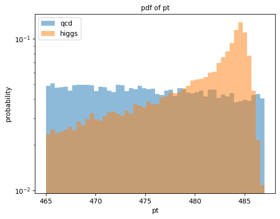

```python
# pt
cut1 = 465
cut2 = 487

mask1 = (qcd_dict['pt'] > cut1) & (qcd_dict['pt'] < cut2)
n_qcd = (qcd_dict['pt'][mask1].shape[0]/5)
mask2 = (higgs_dict['pt'] > cut1) & (higgs_dict['pt'] < cut2)
n_higgs = higgs_dict['pt'][mask2].shape[0]/1000

print(n_higgs/math.sqrt(n_qcd))

plt.hist(qcd_dict['pt'][mask1], bins = 50, density = True, alpha = 0.5)
plt.hist(higgs_dict['pt'][mask2], bins = 50, density = True, alpha = 0.5)
plt.legend(["qcd", "higgs"])
plt.title("pdf of pt", fontsize = 10)
plt.xlabel('pt', fontsize = 10)
plt.ylabel("probability", fontsize = 10)
plt.yscale('log')
print("small discriminative")
```

```
0.7428977956115336
small discriminative
```

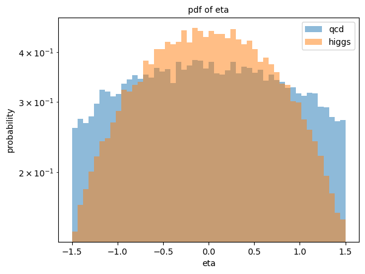

```python
# eta
cut1 = -1.5
cut2 = 1.5

mask1 = (qcd_dict['eta'] > cut1) & (qcd_dict['eta'] < cut2)
n_qcd = (qcd_dict['eta'][mask1].shape[0]/5)
mask2 = (higgs_dict['eta'] > cut1) & (higgs_dict['eta'] < cut2)
n_higgs = higgs_dict['eta'][mask2].shape[0]/1000

print(n_higgs/math.sqrt(n_qcd))

plt.hist(qcd_dict['eta'][mask1], bins = 50, density = True, alpha = 0.5)
plt.hist(higgs_dict['eta'][mask2], bins = 50, density = True, alpha = 0.5)
plt.legend(["qcd", "higgs"])
plt.title("pdf of eta", fontsize = 10)
plt.xlabel('eta', fontsize = 10)
plt.ylabel("probability", fontsize = 10)
plt.yscale('log')
print("small discriminative")
```

```
0.7071067811865475
not discriminative
```

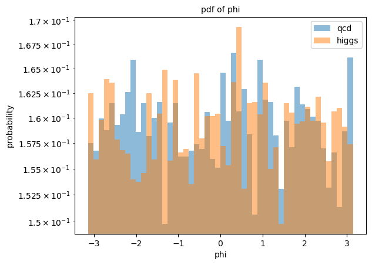

```python
# phi
cut1 = -4
cut2 = 4

mask1 = (qcd_dict['phi'] > cut1) & (qcd_dict['phi'] < cut2)
n_qcd = (qcd_dict['phi'][mask1].shape[0]/5)
mask2 = (higgs_dict['phi'] > cut1) & (higgs_dict['phi'] < cut2)
n_higgs = higgs_dict['phi'][mask2].shape[0]/1000

print(n_higgs/math.sqrt(n_qcd))

plt.hist(qcd_dict['phi'][mask1], bins = 50, density = True, alpha = 0.5)
plt.hist(higgs_dict['phi'][mask2], bins = 50, density = True, alpha = 0.5)
plt.legend(["qcd", "higgs"])
plt.title("pdf of phi", fontsize = 10)
plt.xlabel('phi', fontsize = 10)
plt.ylabel("probability", fontsize = 10)
plt.yscale('log')
print("not discriminative")
```

```
2.422596350179467
very discriminative
```

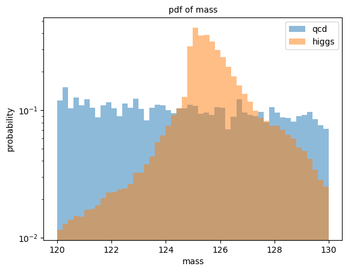

```python
# mass
cut1 = 120
cut2 = 130

mask1 = (qcd_dict['mass'] > cut1) & (qcd_dict['mass'] < cut2)
n_qcd = (qcd_dict['mass'][mask1].shape[0]/5)
mask2 = (higgs_dict['mass'] > cut1) & (higgs_dict['mass'] < cut2)
n_higgs = higgs_dict['mass'][mask2].shape[0]/1000

print(n_higgs/math.sqrt(n_qcd))

plt.hist(qcd_dict['mass'][mask1], bins = 50, density = True, alpha = 0.5)
plt.hist(higgs_dict['mass'][mask2], bins = 50, density = True, alpha = 0.5)
plt.legend(["qcd", "higgs"])
plt.title("pdf of mass", fontsize = 10)
plt.xlabel('mass', fontsize = 10)
plt.ylabel("probability", fontsize = 10)
plt.yscale('log')
print("very discriminative")
```

```
1.1908876364582066
small discriminative
```

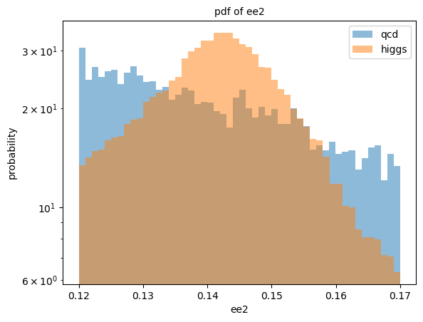

```python
# ee2
cut1 = 0.12
cut2 = 0.17

mask1 = (qcd_dict['ee2'] > cut1) & (qcd_dict['ee2'] < cut2)
n_qcd = (qcd_dict['ee2'][mask1].shape[0]/5)
mask2 = (higgs_dict['ee2'] > cut1) & (higgs_dict['ee2'] < cut2)
n_higgs = higgs_dict['ee2'][mask2].shape[0]/1000

print(n_higgs/math.sqrt(n_qcd))

plt.hist(qcd_dict['ee2'][mask1], bins = 50, density = True, alpha = 0.5)
plt.hist(higgs_dict['ee2'][mask2], bins = 50, density = True, alpha = 0.5)
plt.legend(["qcd", "higgs"])
plt.title("pdf of ee2", fontsize = 10)
plt.xlabel('ee2', fontsize = 10)
plt.ylabel("probability", fontsize = 10)
plt.yscale('log')
print("small discriminative")
```

```
0.896005599715976
small discriminative
```

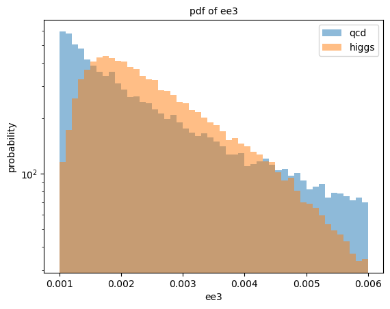

```python
# ee3
cut1 = 0.001
cut2 = 0.006

mask1 = (qcd_dict['ee3'] > cut1) & (qcd_dict['ee3'] < cut2)
n_qcd = (qcd_dict['ee3'][mask1].shape[0]/5)
mask2 = (higgs_dict['ee3'] > cut1) & (higgs_dict['ee3'] < cut2)
n_higgs = higgs_dict['ee3'][mask2].shape[0]/1000

print(n_higgs/math.sqrt(n_qcd))

plt.hist(qcd_dict['ee3'][mask1], bins = 50, density = True, alpha = 0.5)
plt.hist(higgs_dict['ee3'][mask2], bins = 50, density = True, alpha = 0.5)
plt.legend(["qcd", "higgs"])
plt.title("pdf of ee3", fontsize = 10)
plt.xlabel('ee3', fontsize = 10)
plt.ylabel("probability", fontsize = 10)
plt.yscale('log')
print("small discriminative")
```

```
1.2540152704823262
middle discriminative
```

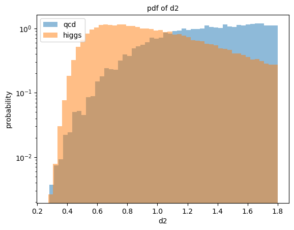

```python
# d2
cut1 = 0.25
cut2 = 1.8

mask1 = (qcd_dict['d2'] > cut1) & (qcd_dict['d2'] < cut2)
n_qcd = (qcd_dict['d2'][mask1].shape[0]/5)
mask2 = (higgs_dict['d2'] > cut1) & (higgs_dict['d2'] < cut2)
n_higgs = higgs_dict['d2'][mask2].shape[0]/1000

print(n_higgs/math.sqrt(n_qcd))

plt.hist(qcd_dict['d2'][mask1], bins = 50, density = True, alpha = 0.5)
plt.hist(higgs_dict['d2'][mask2], bins = 50, density = True, alpha = 0.5)
plt.legend(["qcd", "higgs"])
plt.title("pdf of d2", fontsize = 10)
plt.xlabel('d2', fontsize = 10)
plt.ylabel("probability", fontsize = 10)
plt.yscale('log')
print("middle discriminative")
```

```
0.6216554660430204
not discriminative
```

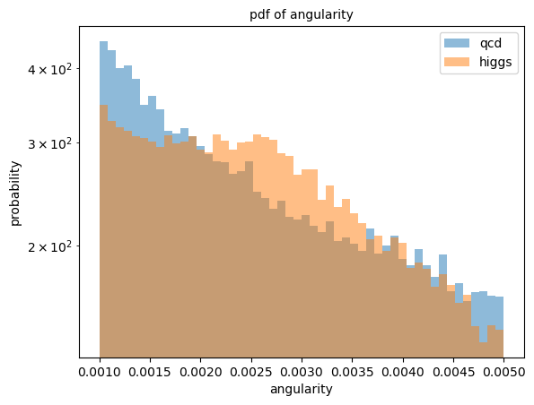

```python
# angularity
cut1 = 0.001
cut2 = 0.005

mask1 = (qcd_dict['angularity'] > cut1) & (qcd_dict['angularity'] < cut2)
n_qcd = (qcd_dict['angularity'][mask1].shape[0]/5)
mask2 = (higgs_dict['angularity'] > cut1) & (higgs_dict['angularity'] < cut2)
n_higgs = higgs_dict['angularity'][mask2].shape[0]/1000

print(n_higgs/math.sqrt(n_qcd))

plt.hist(qcd_dict['angularity'][mask1], bins = 50, density = True, alpha = 0.5)
plt.hist(higgs_dict['angularity'][mask2], bins = 50, density = True, alpha = 0.5)
plt.legend(["qcd", "higgs"])
plt.title("pdf of angularity", fontsize = 10)
plt.xlabel('angularity', fontsize = 10)
plt.ylabel("probability", fontsize = 10)
plt.yscale('log')
print("not discriminative")
```

```
0.5771956535120415
not discriminative
```

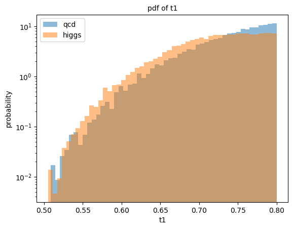

```python
# t1
cut1 = 0.5
cut2 = 0.8

mask1 = (qcd_dict['t1'] > cut1) & (qcd_dict['t1'] < cut2)
n_qcd = (qcd_dict['t1'][mask1].shape[0]/5)
mask2 = (higgs_dict['t1'] > cut1) & (higgs_dict['t1'] < cut2)
n_higgs = higgs_dict['t1'][mask2].shape[0]/1000

print(n_higgs/math.sqrt(n_qcd))

plt.hist(qcd_dict['t1'][mask1], bins = 50, density = True, alpha = 0.5)
plt.hist(higgs_dict['t1'][mask2], bins = 50, density = True, alpha = 0.5)
plt.legend(["qcd", "higgs"])
plt.title("pdf of t1", fontsize = 10)
plt.xlabel('t1', fontsize = 10)
plt.ylabel("probability", fontsize = 10)
plt.yscale('log')
print("not discriminative")
```

```
1.6833922798963723
middle discriminative
```

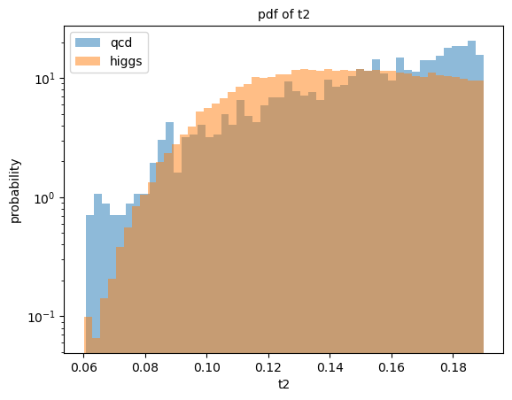

```python
# t2
cut1 = 0.06
cut2 = 0.19

mask1 = (qcd_dict['t2'] > cut1) & (qcd_dict['t2'] < cut2)
n_qcd = (qcd_dict['t2'][mask1].shape[0]/5)
mask2 = (higgs_dict['t2'] > cut1) & (higgs_dict['t2'] < cut2)
n_higgs = higgs_dict['t2'][mask2].shape[0]/1000

print(n_higgs/math.sqrt(n_qcd))

plt.hist(qcd_dict['t2'][mask1], bins = 50, density = True, alpha = 0.5)
plt.hist(higgs_dict['t2'][mask2], bins = 50, density = True, alpha = 0.5)
plt.legend(["qcd", "higgs"])
plt.title("pdf of t2", fontsize = 10)
plt.xlabel('t2', fontsize = 10)
plt.ylabel("probability", fontsize = 10)
plt.yscale('log')
print("middle discriminative")
```

```
1.7036744734732525
middle discriminative
```

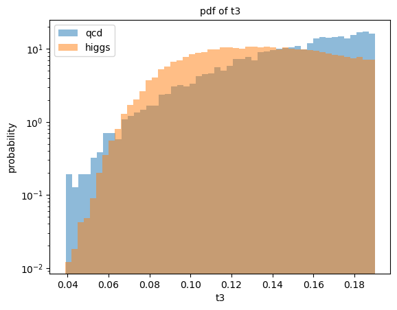

```python
# t3
cut1 = 0.03
cut2 = 0.19

mask1 = (qcd_dict['t3'] > cut1) & (qcd_dict['t3'] < cut2)
n_qcd = (qcd_dict['t3'][mask1].shape[0]/5)
mask2 = (higgs_dict['t3'] > cut1) & (higgs_dict['t3'] < cut2)
n_higgs = higgs_dict['t3'][mask2].shape[0]/1000

print(n_higgs/math.sqrt(n_qcd))

plt.hist(qcd_dict['t3'][mask1], bins = 50, density = True, alpha = 0.5)
plt.hist(higgs_dict['t3'][mask2], bins = 50, density = True, alpha = 0.5)
plt.legend(["qcd", "higgs"])
plt.title("pdf of t3", fontsize = 10)
plt.xlabel('t3', fontsize = 10)
plt.ylabel("probability", fontsize = 10)
plt.yscale('log')
print("middle discriminative")
```

```
1.502937691567876
middle discriminative
```

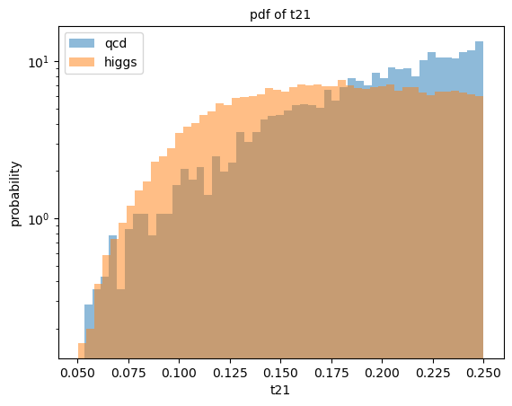

```python
# t21
cut1 = 0.05
cut2 = 0.25

mask1 = (qcd_dict['t21'] > cut1) & (qcd_dict['t21'] < cut2)
n_qcd = (qcd_dict['t21'][mask1].shape[0]/5)
mask2 = (higgs_dict['t21'] > cut1) & (higgs_dict['t21'] < cut2)
n_higgs = higgs_dict['t21'][mask2].shape[0]/1000

print(n_higgs/math.sqrt(n_qcd))

plt.hist(qcd_dict['t21'][mask1], bins = 50, density = True, alpha = 0.5)
plt.hist(higgs_dict['t21'][mask2], bins = 50, density = True, alpha = 0.5)
plt.legend(["qcd", "higgs"])
plt.title("pdf of t21", fontsize = 10)
plt.xlabel('t21', fontsize = 10)
plt.ylabel("probability", fontsize = 10)
plt.yscale('log')
print("middle discriminative")
```

```
0.7118783357810053
not discriminative
```

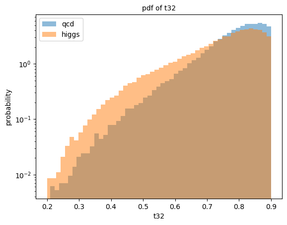

```python
# t32
cut1 = 0.2
cut2 = 0.9

mask1 = (qcd_dict['t32'] > cut1) & (qcd_dict['t32'] < cut2)
n_qcd = (qcd_dict['t32'][mask1].shape[0]/5)
mask2 = (higgs_dict['t32'] > cut1) & (higgs_dict['t32'] < cut2)
n_higgs = higgs_dict['t32'][mask2].shape[0]/1000

print(n_higgs/math.sqrt(n_qcd))

plt.hist(qcd_dict['t32'][mask1], bins = 50, density = True, alpha = 0.5)
plt.hist(higgs_dict['t32'][mask2], bins = 50, density = True, alpha = 0.5)
plt.legend(["qcd", "higgs"])
plt.title("pdf of t32", fontsize = 10)
plt.xlabel('t32', fontsize = 10)
plt.ylabel("probability", fontsize = 10)
plt.yscale('log')
print("not discriminative")
```

```
1.0356280890557508
small discriminative
```

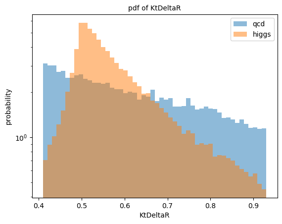

```python
# KtDeltaR
cut1 = 0.41
cut2 = 0.93

mask1 = (qcd_dict['KtDeltaR'] > cut1) & (qcd_dict['KtDeltaR'] < cut2)
n_qcd = (qcd_dict['KtDeltaR'][mask1].shape[0]/5)
mask2 = (higgs_dict['KtDeltaR'] > cut1) & (higgs_dict['KtDeltaR'] < cut2)
n_higgs = higgs_dict['KtDeltaR'][mask2].shape[0]/1000

print(n_higgs/math.sqrt(n_qcd))

plt.hist(qcd_dict['KtDeltaR'][mask1], bins = 50, density = True, alpha = 0.5)
plt.hist(higgs_dict['KtDeltaR'][mask2], bins = 50, density = True, alpha = 0.5)
plt.legend(["qcd", "higgs"])
plt.title("pdf of KtDeltaR", fontsize = 10)
plt.xlabel('KtDeltaR', fontsize = 10)
plt.ylabel("probability", fontsize = 10)
plt.yscale('log')
print("small discriminative")
```

Yes, I can further improve expected significance by including the cut from other notiable discriminative features such as d2, t3, t2, and t21

# Problem 4

```python
masscut1 = 120
masscut2 = 130

d2cut1 = 0.25
d2cut2 = 5

t21cut1 = 0.05
t21cut2 = 0.4

t2cut1 = 0.
t2cut2 = 0.35

mask1 = (higgs_dict['mass'] > masscut1) & (higgs_dict['mass'] < masscut2)\
& (higgs_dict['d2'] > d2cut1) & (higgs_dict['d2'] < d2cut2)\
& (higgs_dict['t21'] > t21cut1) & (higgs_dict['t21'] < t21cut2)\
& (higgs_dict['t2'] > t2cut1) & (higgs_dict['t2'] < t2cut2)\

n_higgs = higgs_dict[mask1].shape[0]/1000

mask2 = (qcd_dict['mass'] > masscut1) & (qcd_dict['mass'] < masscut2)\
& (qcd_dict['d2'] > d2cut1) & (qcd_dict['d2'] < d2cut2)\
& (qcd_dict['t21'] > t21cut1) & (higgs_dict['t21'] < t21cut2)\
& (qcd_dict['t2'] > t2cut1) & (qcd_dict['t2'] < t2cut2)\

n_qcd = (qcd_dict[mask2].shape[0]/5)

print(n_higgs/math.sqrt(n_qcd))
print(n_higgs)
print(n_qcd)
d = stats.poisson(n_qcd)
p = d.cdf(n_higgs+n_qcd)
sigma = stats.norm.ppf(p)
print(sigma)
```

```
4.879322550771703
58.389
143.2
4.600445999228756
```

The sensitivity of the signal increased to 4.6 sigma after applying the cuts on features such as mass, d2, t21, and t2. My partner increased the significance to 5.2 sigma with feature cuts on mass, d2, t21, and KtDeltaR, which is fairly closed to my result. After normalization, I found the number of Higgs that passed the cuts to be 58 (58% preserved), and a number of QCD to be 143 (0.7% preserved).

# Lab 8 Problem 1

I chose four features(mass, d2, t21, and t2) to increase the sensitivity

```python
readHigh = pd.read_hdf('./data_highLumi_pt_250_500.h5')
readLow = pd.read_hdf('./data_lowLumi_pt_250_500.h5')
```

# 8.2 High luminosity data

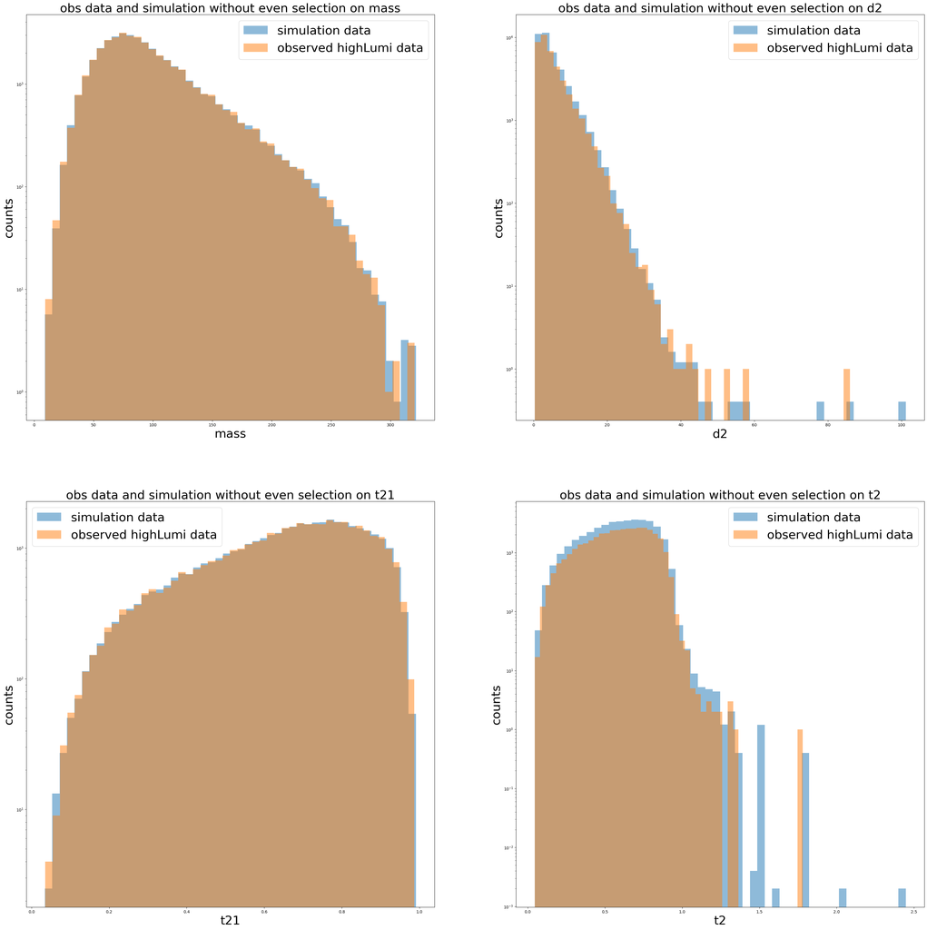

```python
total = higgs_dict.append(qcd_dict)
fig = plt.figure(figsize=(40, 40))

rows = 2
columns = 2
n = 0

weiHiggs = np.full(100000, [1681/837500])
weiqcd = np.full(100000, [3362/8375])

for x in ['mass', 'd2', 't21', 't2']:
    n = n+1
    fig.add_subplot(rows, columns, n)

    plt.hist(total[x], bins = 50, weights = np.append(weiHiggs,weiqcd), alpha = 0.5)
    plt.hist(readHigh[x], bins = 50, alpha = 0.5)


    plt.legend(["simulation data", "observed highLumi data"], fontsize = 30)
    plt.title("obs data and simulation without even selection on " + str(x), fontsize = 30)
    plt.xlabel(str(x), fontsize = 30)
    plt.ylabel("counts", fontsize = 30)
    plt.yscale('log')
```

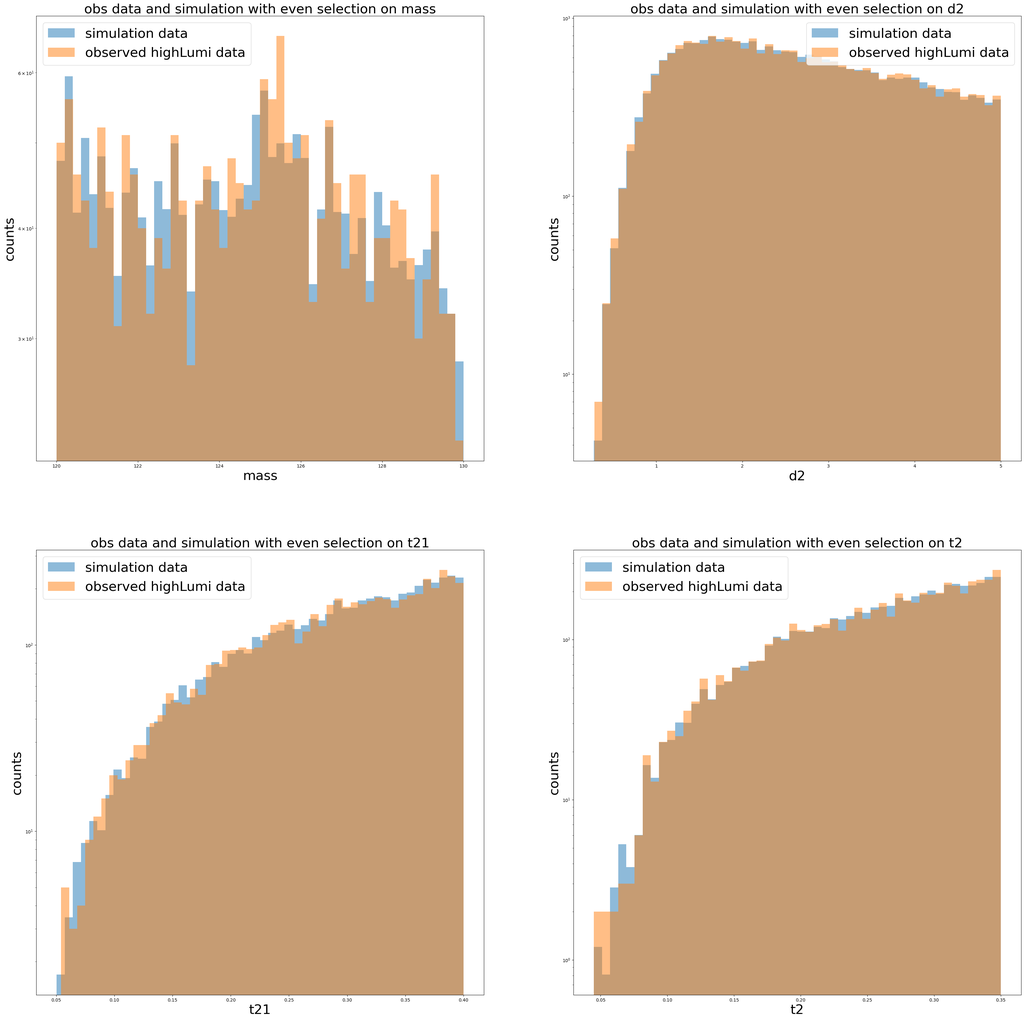

```python
fig = plt.figure(figsize=(40, 40))

rows = 2
columns = 2
n = 0
cuts = [[masscut1, masscut2], [d2cut1, d2cut2], [t21cut1, t21cut2], [t2cut1, t2cut2]]


for x in ['mass', 'd2', 't21', 't2']:
    mask1 = (higgs_dict[x] > cuts[n][0]) & (higgs_dict[x] < cuts[n][1])
    mask2 = (qcd_dict[x] > cuts[n][0]) & (qcd_dict[x] < cuts[n][1])
    mask3 = (readHigh[x] > cuts[n][0]) & (readHigh[x] < cuts[n][1])

    higgsN = higgs_dict[x][mask1].shape[0]
    qcdN = qcd_dict[x][mask2].shape[0]
    highLumiN = readHigh[x][mask3].shape[0]
    total = higgs_dict[x][mask1].append(qcd_dict[x][mask2])

    A = np.array([[higgsN,qcdN], [1,-1/200]])
    B = np.array([highLumiN, 0])
    Ans = np.linalg.inv(A).dot(B)

    higgsWei = np.full(higgsN, [Ans[0]])
    qcdWei = np.full(qcdN, [Ans[1]])
    n = n + 1
    fig.add_subplot(rows, columns, n)

    plt.hist(total, bins = 50, weights = np.append(higgsWei, qcdWei), alpha = 0.5)
    plt.hist(readHigh[x][mask3], bins = 50, alpha = 0.5)

    plt.legend(["simulation data", "observed highLumi data"], fontsize = 30)
    plt.title("obs data and simulation with even selection on " + str(x), fontsize = 30)
    plt.xlabel(str(x), fontsize = 30)
    plt.ylabel("counts", fontsize = 30)
    plt.yscale('log')
```

```python
qcdRatio = (n_qcd*5)/100000
print(qcdRatio)
expectedHighLumiQcd = readHigh.shape[0] * qcdRatio
print(expectedHighLumiQcd)

mask = (readHigh['mass'] > masscut1) & (readHigh['mass'] < masscut2)\
& (readHigh['d2'] > d2cut1) & (readHigh['d2'] < d2cut2)\
& (readHigh['t21'] > t21cut1) & (readHigh['t21'] < t21cut2)\
& (readHigh['t2'] > t2cut1) & (readHigh['t2'] < t2cut2)\

n_highLumi = readHigh[mask].shape[0]
print(n_highLumi)

p = stats.poisson.cdf(k=n_highLumi, mu=expectedHighLumiQcd)
sigma = stats.norm.ppf(p)
print(sigma)
```

```
0.00716
288.86304
406
6.5263171287916295
```

To compare the observed significance and expectation, I first find the percentage of the qcd that passed the cuts (0.71%) and use it as the reference of the number of High luminosity data that would pass the cut, which is 289, and this is the mean of the Poisson distribution. To find the measurement, I then used the same cuts to the high luminosity data and found the number of events passed to be 406. Applied this 289 as the mean and 406 as our measurement and we can find the observed significance to be 6.5 sigma, which is higher than the expected significance (4.6 sigma) that we found from problem 7.4.

# 8.2 Low luminosity data

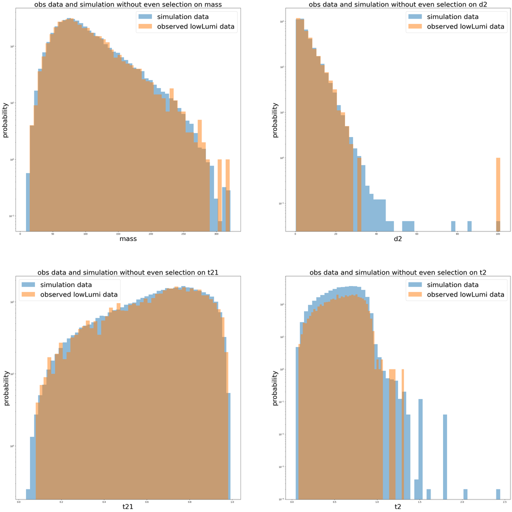

```python
total = higgs_dict.append(qcd_dict)
fig = plt.figure(figsize=(40, 40))

rows = 2
columns = 2
n = 0

weiHiggs = np.full(100000, [203/1005000])
weiqcd = np.full(100000, [203/5025])

for x in ['mass', 'd2', 't21', 't2']:
    n = n+1
    fig.add_subplot(rows, columns, n)

    plt.hist(total[x], bins = 50, weights = np.append(weiHiggs, weiqcd), alpha = 0.5)
    plt.hist(readLow[x], bins = 50, alpha = 0.5)


    plt.legend(["simulation data", "observed lowLumi data"], fontsize = 30)
    plt.title("obs data and simulation without even selection on " + str(x), fontsize = 30)
    plt.xlabel(str(x), fontsize = 30)
    plt.ylabel("probability", fontsize = 30)
    plt.yscale('log')
```

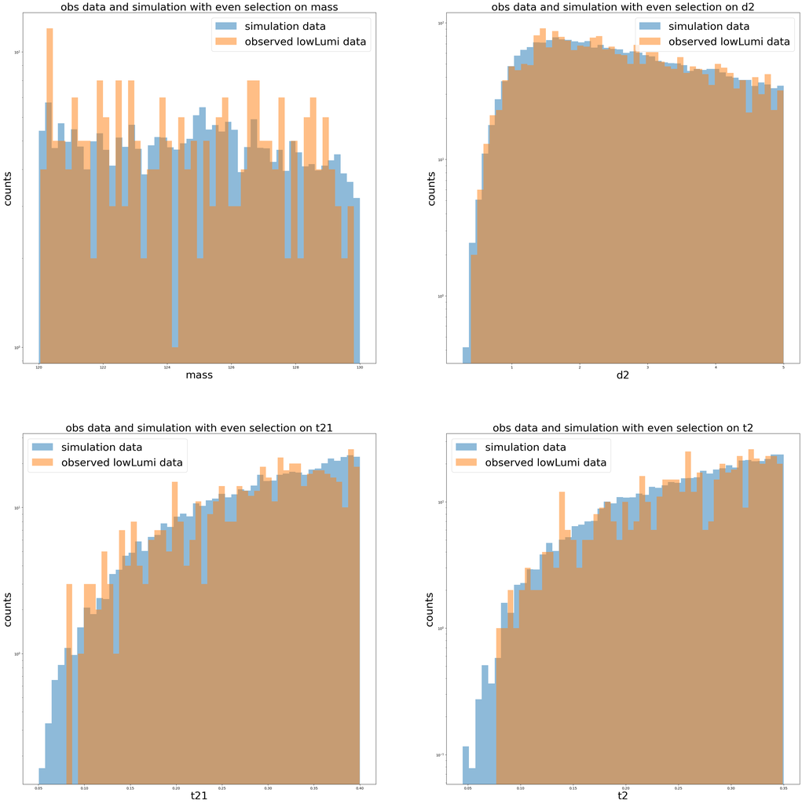

```python
fig = plt.figure(figsize=(40, 40))

rows = 2
columns = 2
n = 0
cuts = [[masscut1, masscut2], [d2cut1, d2cut2], [t21cut1, t21cut2], [t2cut1, t2cut2]]


for x in ['mass', 'd2', 't21', 't2']:
    mask1 = (higgs_dict[x] > cuts[n][0]) & (higgs_dict[x] < cuts[n][1])
    mask2 = (qcd_dict[x] > cuts[n][0]) & (qcd_dict[x] < cuts[n][1])
    mask3 = (readLow[x] > cuts[n][0]) & (readLow[x] < cuts[n][1])

    higgsN = higgs_dict[x][mask1].shape[0]
    qcdN = qcd_dict[x][mask2].shape[0]
    lowLumiN = readLow[x][mask3].shape[0]
    total = higgs_dict[x][mask1].append(qcd_dict[x][mask2])

    A = np.array([[higgsN,qcdN], [1,-1/200]])
    B = np.array([lowLumiN, 0])
    Ans = np.linalg.inv(A).dot(B)

    higgsWei = np.full(higgsN, [Ans[0]])
    qcdWei = np.full(qcdN, [Ans[1]])
    n = n + 1
    fig.add_subplot(rows, columns, n)

    plt.hist(total, bins = 50, weights = np.append(higgsWei, qcdWei), alpha = 0.5)
    plt.hist(readLow[x][mask3], bins = 50, alpha = 0.5)

    plt.legend(["simulation data", "observed lowLumi data"], fontsize = 30)
    plt.title("obs data and simulation with even selection on " + str(x), fontsize = 30)
    plt.xlabel(str(x), fontsize = 30)
    plt.ylabel("counts", fontsize = 30)
    plt.yscale('log')
```

```python
qcdRatio = (n_qcd*5)/100000
print(qcdRatio)
expectedLowLumiQcd = readLow.shape[0] * qcdRatio
print(expectedLowLumiQcd)

mask = (readLow['mass'] > masscut1) & (readLow['mass'] < masscut2)\
& (readLow['d2'] > d2cut1) & (readLow['d2'] < d2cut2)\
& (readLow['t21'] > t21cut1) & (readLow['t21'] < t21cut2)\
& (readLow['t2'] > t2cut1) & (readLow['t2'] < t2cut2)\

n_lowLumi = readLow[mask].shape[0]
print(n_lowLumi)

p = stats.poisson.cdf(k=n_lowLumi, mu=expectedLowLumiQcd)
sigma = stats.norm.ppf(p)
print(sigma)
```

```
0.00716
29.069599999999998
45
2.8409076655281646
```

Similar to the steps above, I first find the percentage of the qcd that passed the cuts (0.71%) and use it as the reference of the number of Low luminosity data that would pass the cut, which is 29, and this is the mean of the Poisson distribution. To find the measurement, I applied the same cuts to the low luminosity data and found the number of events passed to be 45. I then used 29 as the mean and 45 as our measurement and we can find the observed significance to be 2.8 sigma, which is lower than the expected significance.

# 95% Confidence Level of signal yields

```python
expUpperLim = stats.poisson(mu = 58).ppf(0.95)
print(expUpperLim)
```

```
71.0
```

```python
expUpperLim = stats.poisson(mu = 29).ppf(0.95)
print(expUpperLim)
```

```
38.0
```

The expected 95% confidence level upper limit is 71, whereas the observed 95% confidence level upper limit is 38. The observed signal is likely to be smaller than the expected signal, making the observed signal biased.

```python
oneSigma = stats.poisson(mu = 58).ppf(0.68)
print(oneSigma)
oneSigma = stats.poisson(mu = 58).ppf(0.34)
print(oneSigma)
```

```
61.0
55.0
```